# Fisseha Berhane, PhD

#### Data Scientist

443-970-2353 fisseha@jhu.edu CV Resume

## Machine Learning with Python scikit-learn Vs R Caret - Part 1

This blog post series is on machine learning with Python and R. We will use the **Scikit-learn** library in Python and the **Caret** package in R. In this part, we will first perform exploratory Data Analysis (EDA) on a real-world dataset, and then apply non-regularized linear regression to solve a supervised regression problem on the dataset. We will predict power output given a set of environmental readings from various sensors in a natural gas-fired power generation plant. In the second part of the post, we will work with regularized linear regression models (ridge, lasso and elasticnet). Next, we will see the other non-linear regression models.

The real-world data we are using in this post consists of 9,568 data points, each with 4 environmental attributes collected from a Combined Cycle Power Plant over 6 years (2006-2011), and is provided by the [University of California, Irvine at UCI Machine Learning Repository Combined Cycle Power Plant Data Set](https://archive.ics.uci.edu/ml/datasets/Combined+Cycle+Power+Plant). You can find more details about the dataset on the UCI page. The task is a regression problem since the label (or target) we are trying to predict is numeric.

### R Caret

Import libraries to perfrom Extract-Transform-Load (ETL) and Exploratory Data Analysis (EDA)

The caret package (short for _C_lassification _A_nd _RE_gression _T_raining) is a set of functions that attempt to streamline the process for creating predictive models.

```python
import pandas as pd
import seaborn as sns
import statsmodels.api as sm
import matplotlib.pyplot as plt
plt.style.use('ggplot') # if you are an R user and want to feel at home
```

```python
library(readxl)
library(ggplot2)
library(corrplot)
library(tidyverse)
```

**Load Data**

```python
power_plant = pd.read_excel("Folds5x2_pp.xlsx")
```

```python
power_plant = read_excel("Folds5x2_pp.xlsx")
```

**Exploratory Data Analysis (EDA)**

This is a step that we should always perform before trying to fit a model to the data, as this step will often lead to important insights about our data.

```python
type(power_plant)
```

```
pandas.core.frame.DataFrame
```

```python
class(power_plant)
```

1. 'tbl_df'

2. 'tbl'

3. 'data.frame'

```python
# See first few rows

power_plant.head()
```

|  | AT | V | AP | RH | PE |
| --- | --- | --- | --- | --- | --- |
| 0 | 14.96 | 41.76 | 1024.07 | 73.17 | 463.26 |
| 1 | 25.18 | 62.96 | 1020.04 | 59.08 | 444.37 |
| 2 | 5.11 | 39.40 | 1012.16 | 92.14 | 488.56 |
| 3 | 20.86 | 57.32 | 1010.24 | 76.64 | 446.48 |
| 4 | 10.82 | 37.50 | 1009.23 | 96.62 | 473.90 |

```python
# Caret faces problems working with tbl,
# so let's change the data to simple data frame

power_plant = data.frame(power_plant)
message("The class is now ", class(power_plant))

# See first few rows
head(power_plant)
```

```
The class is now data.frame
```

| AT | V | AP | RH | PE |
| --- | --- | --- | --- | --- |
| 14.96 | 41.76 | 1024.07 | 73.17 | 463.26 |
| 25.18 | 62.96 | 1020.04 | 59.08 | 444.37 |
| 5.11 | 39.40 | 1012.16 | 92.14 | 488.56 |
| 20.86 | 57.32 | 1010.24 | 76.64 | 446.48 |
| 10.82 | 37.50 | 1009.23 | 96.62 | 473.90 |
| 26.27 | 59.44 | 1012.23 | 58.77 | 443.67 |

**The columns in the DataFrame are:**

AT = Atmospheric Temperature in C

V = Exhaust Vacuum Speed

AP = Atmospheric Pressure

RH = Relative Humidity

PE = Power Output

Power Output is the value we are trying to predict given the measurements above.

```python
# Size of  DataFrame

power_plant.shape   # we have 9568 rows and 5 columns
```

```
(9568, 5)
```

```python
dim(power_plant)

# we have 9568 rows and 5 columns
```

1. 9568

2. 5

```python
# class of each column in the DataFrame

power_plant.dtypes    # all columns are numeric
```

```
AT    float64
V     float64
AP    float64
RH    float64
PE    float64
dtype: object
```

```python
map(power_plant, class)

# all columns are numeric
```

**$AT**

'numeric'

**$V**

'numeric'

**$AP**

'numeric'

**$RH**

'numeric'

**$PE**

'numeric'

```python
# Are there any missing values in any of the columns?

power_plant.info()  # There is no missing data in all of the columns
```

```
<class 'pandas.core.frame.DataFrame'>
RangeIndex: 9568 entries, 0 to 9567
Data columns (total 5 columns):
AT    9568 non-null float64
V     9568 non-null float64
AP    9568 non-null float64
RH    9568 non-null float64
PE    9568 non-null float64
dtypes: float64(5)
memory usage: 373.8 KB
```

```python
# Check for missing values

map(power_plant, ~sum(is.na(.)))  # using purrr package

# There is no missing data in all of the columns
```

**$AT**

0

**$V**

0

**$AP**

0

**$RH**

0

**$PE**

0

**Visualize relationship between variables**

Before we perform any modeling, it is a good idea to explore correlations between the predictors and the predictand. This step can be important as it helps us to select appropriate models. If our features and the outcome are linearly related, we may start with linear regression models. However, if the relationships between the label and the features are non-linear, non-linear ensemble models such as random forest can be better.

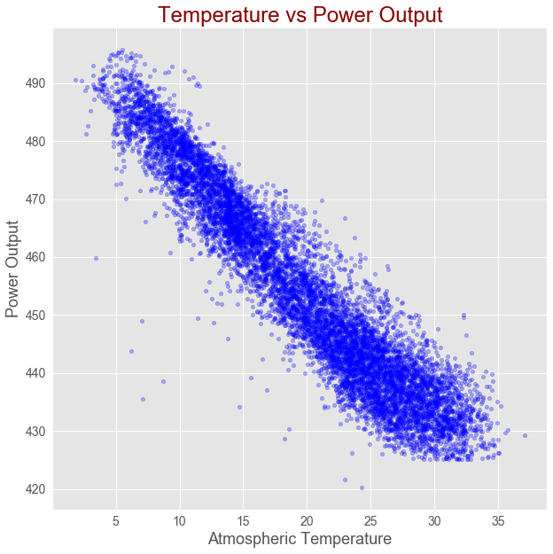

```python
# Correlation between power output and temperature


power_plant.plot(x ='AT', y = 'PE', kind ="scatter",
                 figsize = [10,10],
                 color ="b", alpha = 0.3,
                fontsize = 14)
plt.title("Temperature vs Power Output",
          fontsize = 24, color="darkred")

plt.xlabel("Atmospheric Temperature", fontsize = 18)

plt.ylabel("Power Output", fontsize = 18)

plt.show()
```

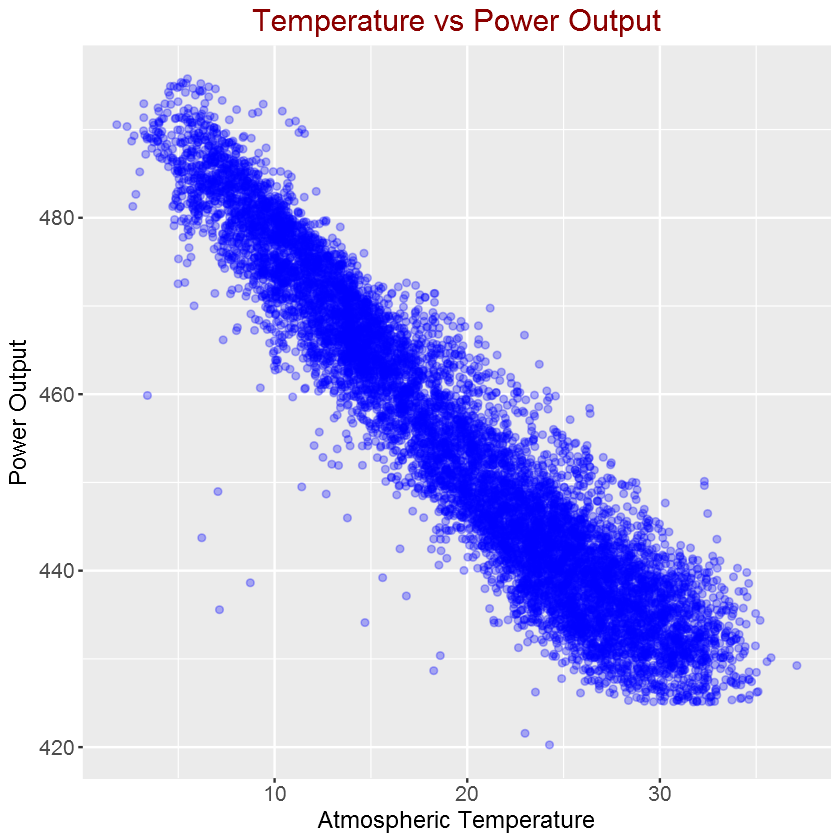

```python
# Correlation between atmospheric temperature and
# power output

power_plant %>% ggplot(aes(AT, PE)) +
    geom_point(color= "blue", alpha = 0.3) +
    ggtitle("Temperature vs Power Output") +
    xlab("Atmospheric Temperature") +
    ylab("Power Output") +
    theme(plot.title = element_text(color="darkred",
                                    size=18,hjust = 0.5),
                     axis.text.y = element_text(size=12),
                      axis.text.x = element_text(size=12,hjust=.5),
                      axis.title.x = element_text(size=14),
                      axis.title.y = element_text(size=14))
```

As shown in the above figure, there is strong linear correlation between Atmospheric Temperature and Power Output.

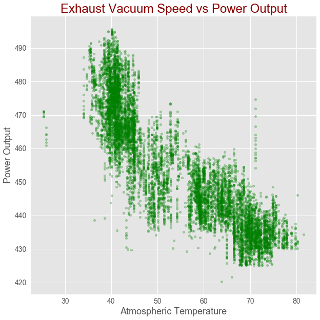

```python
# Correlation between Exhaust Vacuum Speed and power output

power_plant.plot(x ='V', y = 'PE',kind ="scatter",
                 figsize = [10,10],
                 color ="g", alpha = 0.3,
                fontsize = 14)

plt.title("Exhaust Vacuum Speed vs Power Output", fontsize = 24, color="darkred")

plt.xlabel("Atmospheric Temperature", fontsize = 18)

plt.ylabel("Power Output", fontsize = 18)

plt.show()
```

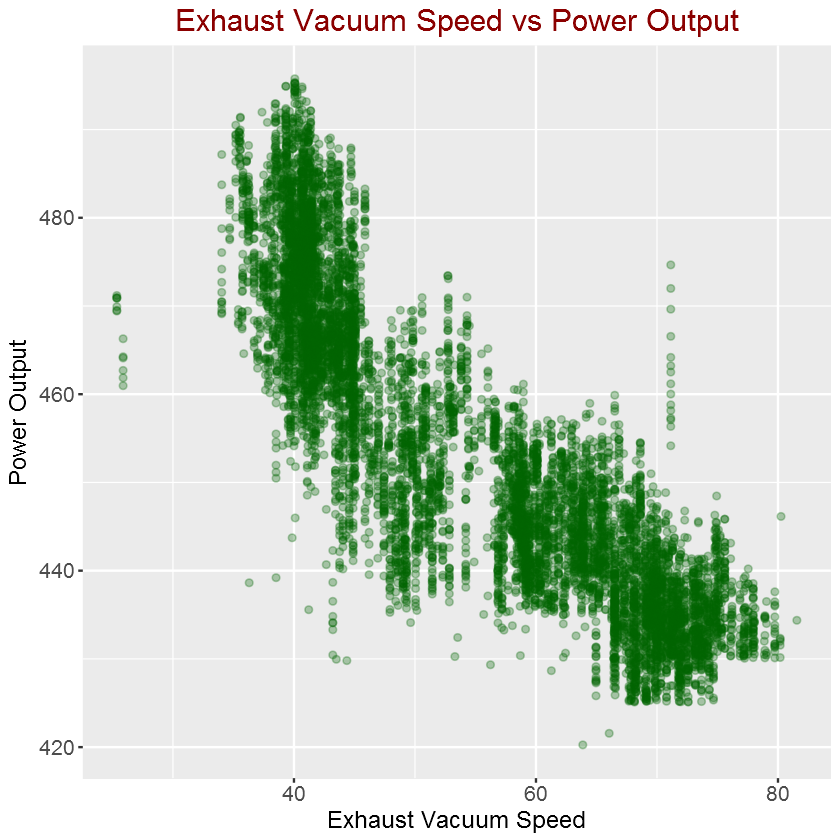

```python
# Correlation between Exhaust Vacuum Speed
# and power output

power_plant %>% ggplot(aes(V, PE)) +
    geom_point(color= "darkgreen", alpha = 0.3) +
    ggtitle("Exhaust Vacuum Speed vs Power Output") +
    xlab("Exhaust Vacuum Speed") +
    ylab("Power Output") +
    theme(plot.title = element_text(color="darkred",size=18,hjust = 0.5),
                     axis.text.y = element_text(size=12),
                      axis.text.x = element_text(size=12,hjust=.5),
                      axis.title.x = element_text(size=14),
                      axis.title.y = element_text(size=14))
```

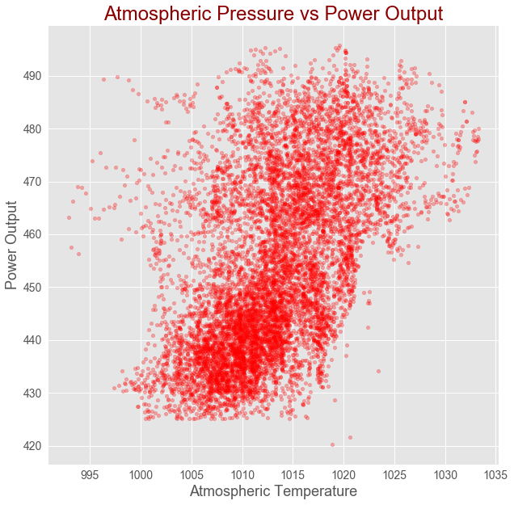

```python
power_plant.plot(x ='AP', y = 'PE',kind ="scatter",
                 figsize = [10,10],
                 color ="r", alpha = 0.3,
                fontsize = 14)

plt.title("Atmospheric Pressure vs Power Output", fontsize = 24, color="darkred")

plt.xlabel("Atmospheric Temperature", fontsize = 18)

plt.ylabel("Power Output", fontsize = 18)

plt.show()
```

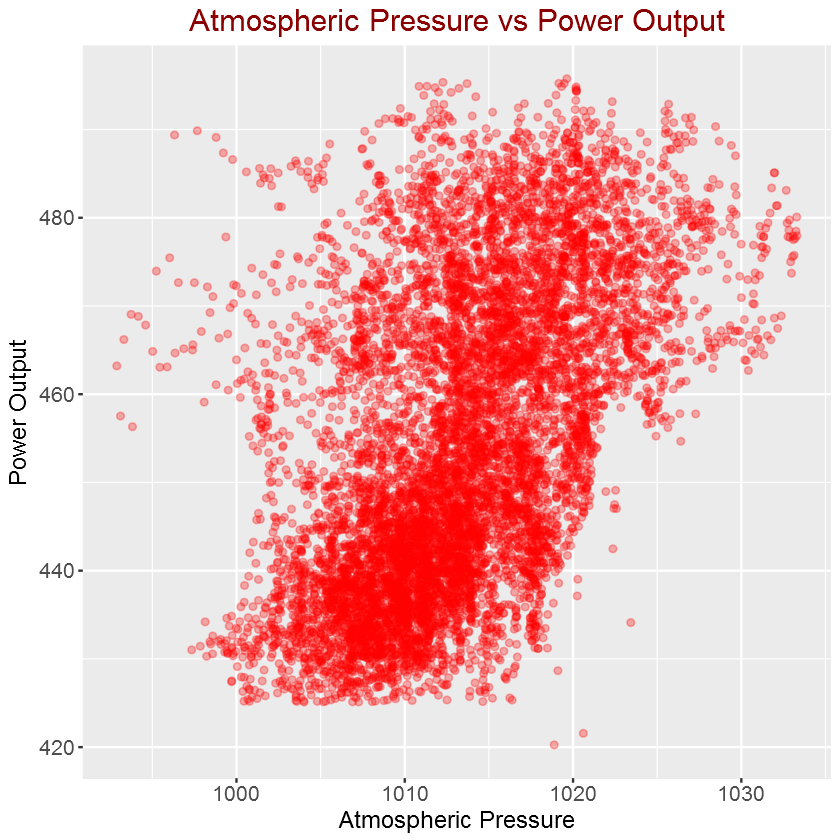

```python
# Correlation between atmospheric pressure
# and power output

power_plant %>% ggplot(aes(AP, PE)) +
    geom_point(color= "red", alpha = 0.3) +
    ggtitle("Atmospheric Pressure vs Power Output") +
    xlab("Atmospheric Pressure") +
    ylab("Power Output") +
    theme(plot.title = element_text(color="darkred",size=18,hjust = 0.5),
                     axis.text.y = element_text(size=12),
                      axis.text.x = element_text(size=12,hjust=.5),
                      axis.title.x = element_text(size=14),
                      axis.title.y = element_text(size=14))
```

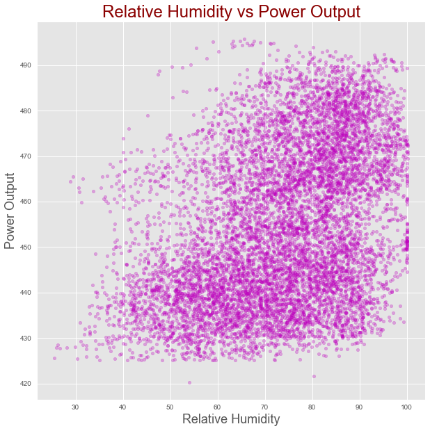

```python
# Correlation between relative humidity
# and power output

power_plant.plot(x ='RH', y = 'PE',kind ="scatter",
                 figsize = [10,10],
                 color ="m", alpha = 0.3)

plt.title("Relative Humidity vs Power Output", fontsize = 24, color="darkred")

plt.xlabel("Relative Humidity", fontsize = 18)

plt.ylabel("Power Output", fontsize = 18)

plt.show()
```

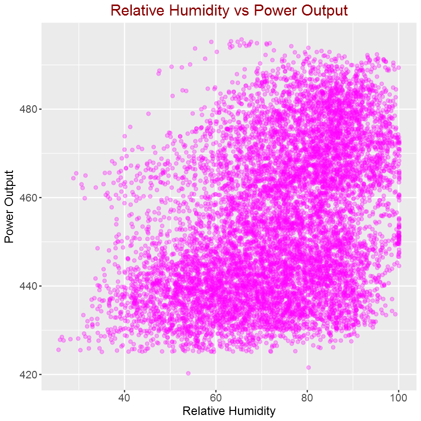

```python
# Correlation between relative humidity
# and power output

power_plant %>% ggplot(aes(RH, PE)) +
    geom_point(color= "magenta", alpha = 0.3) +
    ggtitle("Relative Humidity vs Power Output") +
    xlab("Relative Humidity") +
    ylab("Power Output") +
    theme(plot.title = element_text(color="darkred",size=18,hjust = 0.5),
                     axis.text.y = element_text(size=12),
                      axis.text.x = element_text(size=12,hjust=.5),
                      axis.title.x = element_text(size=14),
                      axis.title.y = element_text(size=14))
```

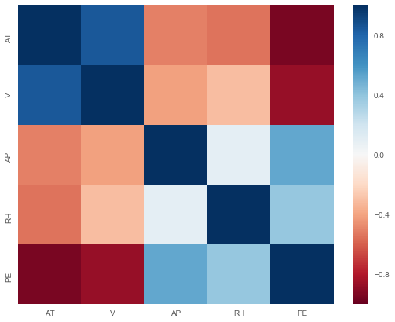

```python
# correlation heatmap

corr = power_plant.corr()
plt.figure(figsize = (9, 7))
sns.heatmap(corr, cmap="RdBu",
            xticklabels=corr.columns.values,
            yticklabels=corr.columns.values)
plt.show()
```

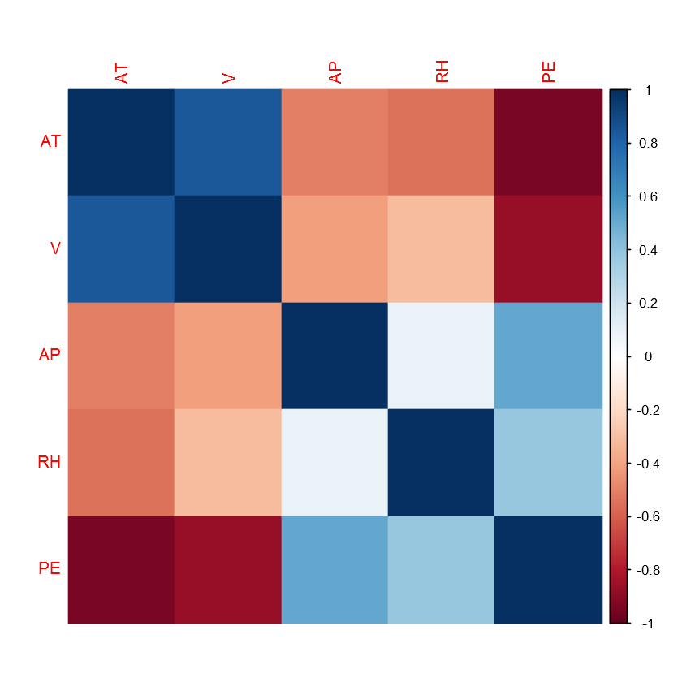

```python
# We can also see the corrleation between
# the various variables using a correlation heatmap

correlations = cor(power_plant)
corrplot(correlations, method="color")
```

As shown in the correlation heatmap above, the target is correlated with the features. However, we also observe correlation among the features, hence we have multi-collinearity problem. He will use regularization to check if the collinearity we observe has a significant impact on the performance of linear regression model.

#### Data Modeling

All the columns are numeric and there are no missing values, which makes our modeling task strightforward.

Now, let's model our data to predict what the power output will be given a set of sensor readings. Our first model will be based on simple linear regression since we saw some linear patterns in our data based on the scatter plots and correlation heatmap during the exploration stage.

We need a way of evaluating how well our linear regression model predicts power output as a function of input parameters. We can do this by splitting up our initial data set into a Training Set, used to train our model and a Test Set, used to evaluate the model's performance in giving predictions.

```python
from sklearn.model_selection import train_test_split
from sklearn.model_selection import cross_val_score
from sklearn.model_selection import GridSearchCV
from sklearn.preprocessing import StandardScaler

from sklearn.pipeline import Pipeline

from sklearn.linear_model import LinearRegression
from sklearn.linear_model import Ridge
from sklearn.linear_model import Lasso
from sklearn.linear_model import ElasticNet

from sklearn.tree import DecisionTreeRegressor

from sklearn.ensemble import RandomForestRegressor
from sklearn.ensemble import GradientBoostingRegressor

from sklearn.svm import SVR

from sklearn.metrics import mean_squared_error

import numpy as np
```

```python
library(caret)


# Caret streamlines the process for creating predictive models.

# The package contains tools for:

#  data splitting
#  pre-processing
#  feature selection
#  model tuning using resampling
#  variable importance estimation
#  as well as other functionality.
```

#### Split data into training and test datasets

Let's split the original dataset into training and test datasets. The training dataset is 80% of the whole dataset, the test set is the remaining 20% of the original dataset. In Python, we use the **train_test_split** function to acheieve that.

In R, the Caret **createDataPartition** function creates indices for training and test portion of the data for us.

```python
X = power_plant.drop("PE", axis = 1).values
y = power_plant['PE'].values
y = y.reshape(-1, 1)

# Split into training and test set
# 80% of the input for training and 20% for testing

X_train, X_test, y_train, y_test = train_test_split(X, y,
                                               test_size = 0.2,
                                               random_state=42)

Training_to_original_ratio = round(X_train.shape[0]/(power_plant.shape[0]), 2) * 100

Testing_to_original_ratio = round(X_test.shape[0]/(power_plant.shape[0]), 2) * 100

print ('As shown below {}% of the data is for training and the rest {}% is for testing.'.format(Training_to_original_ratio,
                                                                                               Testing_to_original_ratio))
list(zip(["Training set", "Testing set"],
   [Training_to_original_ratio, Testing_to_original_ratio]))
```

```
As shown below 80.0% of the data is for training and the rest 20.0% is for testing.
```

```
[('Training set', 80.0), ('Testing set', 20.0)]
```

```python
# create training set indices with 80% of data

set.seed(100)  # For reproducibility

# Create index for testing and training data
inTrain <- createDataPartition(y = power_plant$PE,
                               p = 0.8, list = FALSE)

# subset power_plant data to training
training <- power_plant[inTrain,]


# subset the rest to test
 testing <- power_plant[-inTrain,]


# Size ratio of training and test dataset
message("As shown below, the training set is about 80%  and the test set is about 20% of the original data")

rbind("Training set" = nrow(training)/nrow(power_plant),
      "Testing set" = nrow(testing)/nrow(power_plant)) %>%
       round(2)*100
```

```
As shown below, the training set is about 80%  and the test set is about 20% of the original data
```

| Training set | 80 |
| --- | --- |
| Testing set | 20 |

### Linear Regression

```python
# Instantiate linear regression: reg
# Standardize features by removing the mean
# and scaling to unit variance using the
# StandardScaler() function

# Apply Scaling to X_train and X_test

std_scale = StandardScaler().fit(X_train)
X_train_scaled = std_scale.transform(X_train)
X_test_scaled = std_scale.transform(X_test)

linear_reg = LinearRegression()
reg_scaled = linear_reg.fit(X_train_scaled, y_train)
y_train_scaled_fit = reg_scaled.predict(X_train_scaled)

print("R-squared for training dataset:{}".
      format(np.round(reg_scaled.score(X_train_scaled, y_train),
                      2)))


print("Root mean square error: {}".
      format(np.round(np.sqrt(mean_squared_error(y_train,
                                        y_train_scaled_fit)), 2)))

coefficients = reg_scaled.coef_
features = list(power_plant.drop("PE", axis = 1).columns)

print(" ")
print('The coefficients of the features from the linear model:')
print(dict(zip(features, coefficients[0])))

print("")

print("The intercept is {}".format(np.round(reg_scaled.intercept_[0],3)))
```

```
R-squared for training dataset:0.93
Root mean square error: 4.57

The coefficients of the features from the linear model:
{'AT': -14.763927385645419, 'V': -2.9496320985616462, 'AP': 0.36978031656087407, 'RH': -2.3121956560685817}

The intercept is 454.431
```

```python
## Linear Regression
# Fit linear regression model
# put the predictors on the same scale: mean of zero and unit variance

my_lm <- train(training[,1:4], training[,5],
               method = "lm",
               preProc = c("center", "scale")
              )


message("Linear Regression: Model performance on \n the training set")

my_lm$results[c("RMSE","Rsquared")] %>%
        round(2)

summary(my_lm)
```

```
Linear Regression: Model performance on
 the training set
```

| RMSE | Rsquared |
| --- | --- |
| 4.61 | 0.93 |

```
Call:
lm(formula = .outcome ~ ., data = dat)

Residuals:
    Min      1Q  Median      3Q     Max
-43.281  -3.164  -0.117   3.239  17.704

Coefficients:
             Estimate Std. Error  t value Pr(>|t|)
(Intercept) 454.39620    0.05233 8683.725  < 2e-16 ***
AT          -14.62996    0.12728 -114.943  < 2e-16 ***
V            -3.03266    0.10347  -29.309  < 2e-16 ***
AP            0.39110    0.06320    6.189 6.38e-10 ***
RH           -2.23520    0.06804  -32.849  < 2e-16 ***
---
Signif. codes:  0 '***' 0.001 '**' 0.01 '*' 0.05 '.' 0.1 ' ' 1

Residual standard error: 4.579 on 7651 degrees of freedom
Multiple R-squared:  0.9281,	Adjusted R-squared:  0.9281
F-statistic: 2.469e+04 on 4 and 7651 DF,  p-value: < 2.2e-16
```

```
R-squared for test dataset:0.93
Root mean square error for test dataset: 4.5
```

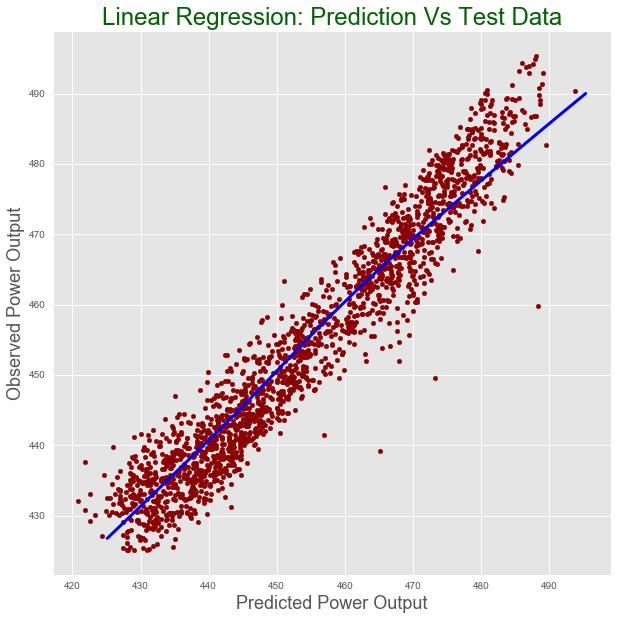

```python
# Predict using the test data

pred = reg_scaled.predict(X_test_scaled)

print("R-squared for test dataset:{}".
      format(np.round(reg_scaled.score(X_test_scaled,
                                       y_test),  2)))


print("Root mean square error for test dataset: {}".
      format(np.round(np.sqrt(mean_squared_error(y_test,
                                        pred)), 2)))


data =  {"prediction": pred, "observed": y_test}

test = pd.DataFrame(pred, columns = ["Prediction"])

test["Observed"] = y_test


lowess = sm.nonparametric.lowess

z = lowess(pred.flatten(), y_test.flatten())


test.plot(figsize = [10,10],
          x ="Prediction", y = "Observed", kind = "scatter", color = 'darkred')

plt.title("Linear Regression: Prediction Vs Test Data", fontsize = 24, color = "darkgreen")

plt.xlabel("Predicted Power Output", fontsize = 18)

plt.ylabel("Observed Power Output", fontsize = 18)

plt.plot(z[:,0], z[:,1], color = "blue", lw= 3)

plt.show()
```

```
R_squared on the test data:
```

0.93

```
Root mean square error on the test data:
```

4.48

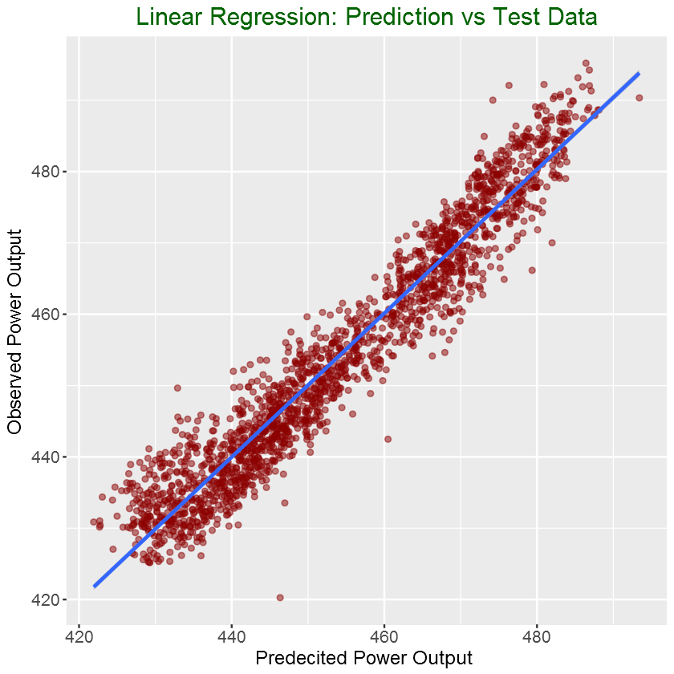

```python
# Predict using the test data

pred <- predict(my_lm, testing[, 1:4])

SSE = sum((testing[,5] -pred)^2)    # sum of squared errors
SST = sum((testing[,5] - mean(training[,5]))^2) # total sum of squares, remember to use training data here

R_square = 1 - SSE/SST
message('R_squared on the test data:')
round(R_square, 2)

SSE = sum((testing[,5] - pred)^2)
RMSE = sqrt(SSE/length(pred))

message("Root mean square error on the test data: ")
round(RMSE, 2)

# Preparing data for ploting
my_data = as.data.frame(cbind(predicted = pred,
                            observed = testing$PE))

# Plot predictions vs test data
ggplot(my_data,aes(predicted, observed)) +
      geom_point(color = "darkred", alpha = 0.5) +
      geom_smooth(method=lm)+ ggtitle('Linear Regression ') +
      ggtitle("Linear Regression: Prediction vs Test Data") +
      xlab("Predecited Power Output ") +
      ylab("Observed Power Output") +
      theme(plot.title = element_text(color="darkgreen",size=18,hjust = 0.5),
                     axis.text.y = element_text(size=12),

            axis.text.x = element_text(size=12,hjust=.5),
                      axis.title.x = element_text(size=14),
                      axis.title.y = element_text(size=14))
```

#### This blog post series is on machine learning with Python and R. In this first post, we saw non-regularized multivariate linear regression. In the second part of the post, we will work with regularized linear regression models. Next, we will see the other non-linear regression models. See you in the next post.

[comments powered by Disqus](http://disqus.com)